# Graduation Cohort Update

Evan Kramer

August 2, 2019

### Document Overview

This document provides a snapshot of the graduation cohort numbers and highlights red flags.

### Uploaded Documents

Districts have uploaded **13138** documents, and we have reviewed **13137** of them (**100**%). If all students who are currently eligible for removal remain so, there would be **15385** documents to review.

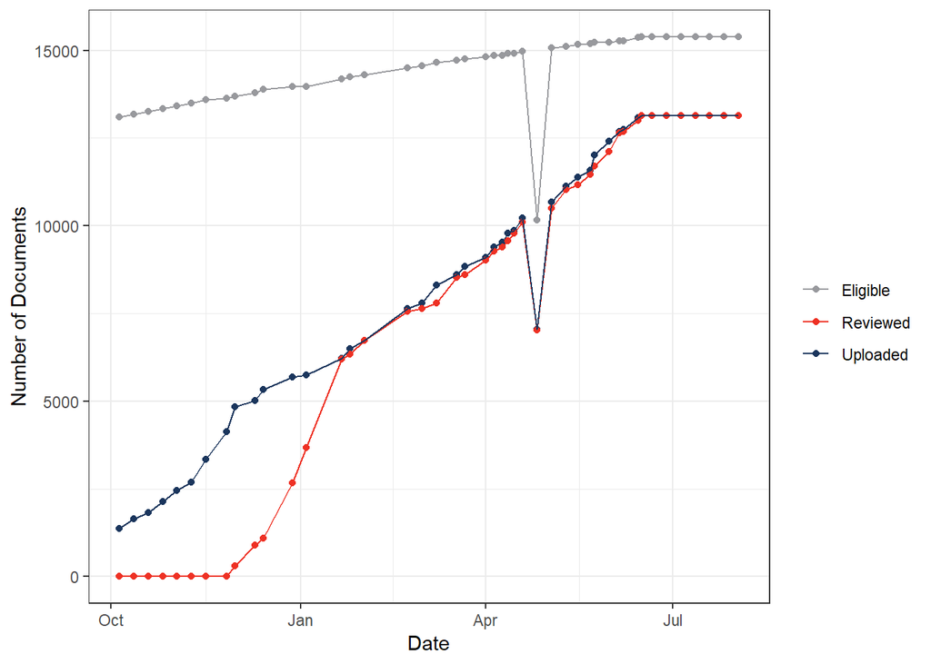

So far we have reviewed about **8** documents per day. At that rate, it would take us **0** days to review all remaining documents (August 2). If districts submit documents for all currently eligible students, it would take us **281** days to review them (May 9).

### Comparison to Prior Year

Districts have uploaded **418 more** documents compared to about this time last year. The deadline to upload documentation has passed.

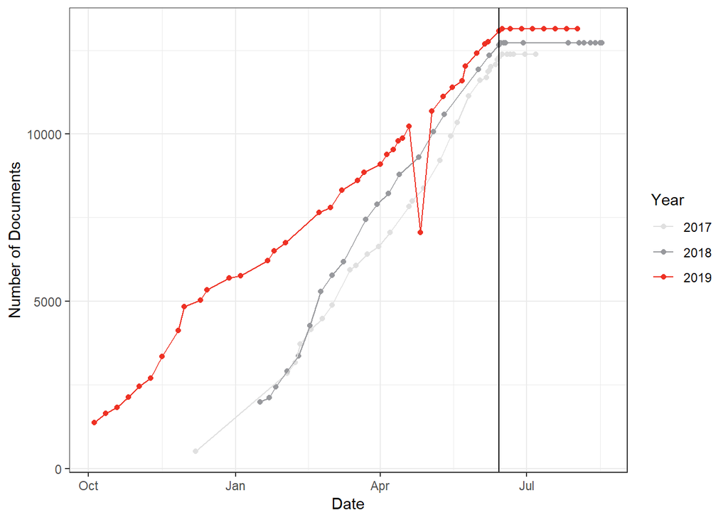

We have reviewed **419 more** documents than about this time last year.

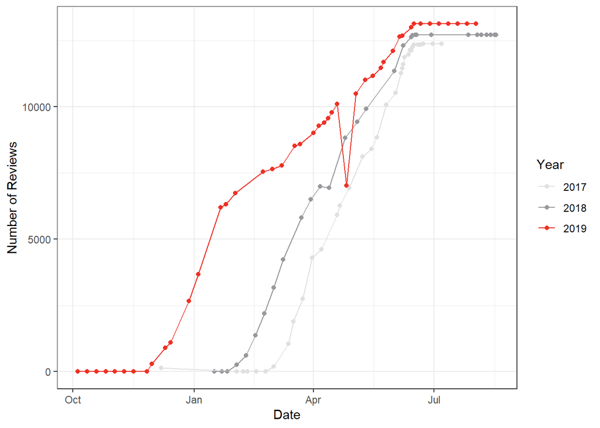

### Document Approval Rates

Overall we have approved **98.9%** of the documents we have reviewed. There are currently **2** districts with high percentages of denied documents (20% or more), and there are **0** students whose documentation must be reviewed again (i.e., the initial submission was denied but the district subsequently submitted a new document). Additionally, there are **0** students whose withdrawal codes have been corrected and must be verified and recorded in the cohort.

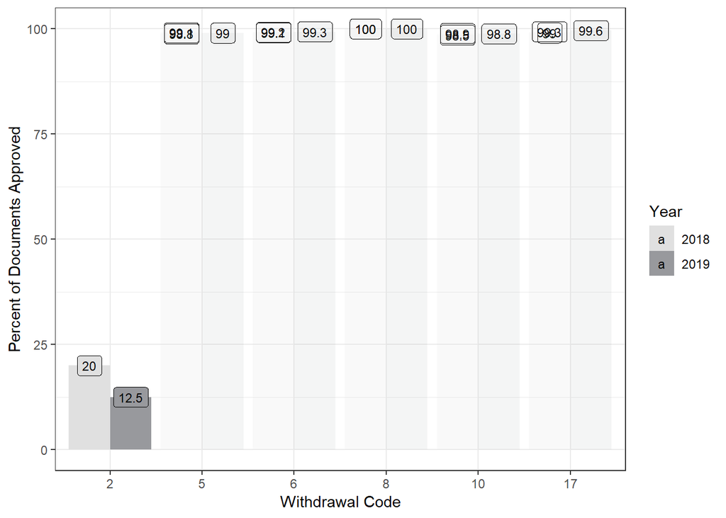